# rbasic_20190916_101_kim

## 4.4. For-loops

```r
compute_s_n <- function(n){
  x <- 1:n
  sum(x)
}
```

How can we compute this for various values of n, say n = 1,…,25? Do we write 25 lines of code calling `compute_s_n`? That is what for-loops are for in programming. We are performing exactly the same task over and over, and the only thing that is changing is the value of n. **For-loops let us define the range that our variable takes, then change the value and evaluate expression as you `loop`**.

```r
for (i in 1:5){
  print(i)
}
```

```
[1] 1
[1] 2
[1] 3
[1] 4
[1] 5
```

```r
m <- 25
s_n <- vector(length = m)
for(n in 1:m){
  s_n[n] <- compute_s_n(n)
}
```

We compute Sn and store it in the nth entry of `s_n`. Now we can create a plot to search for a pattern :

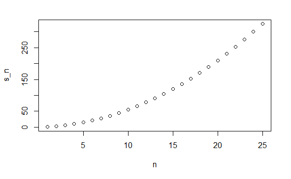

```r
n <- 1:m
plot(n, s_n)
```

```r
head(data.frame(s_n = s_n, formula = n*(n+1)/2))
```

|  | s_n | formula |
| --- | --- | --- |
| 1 | 1 | 1 |
| 2 | 3 | 3 |
| 3 | 6 | 6 |
| 4 | 10 | 10 |
| 5 | 15 | 15 |
| 6 | 21 | 21 |

We can also overlay the two results by using the function `lines` to draw a line over the previously plotted points:

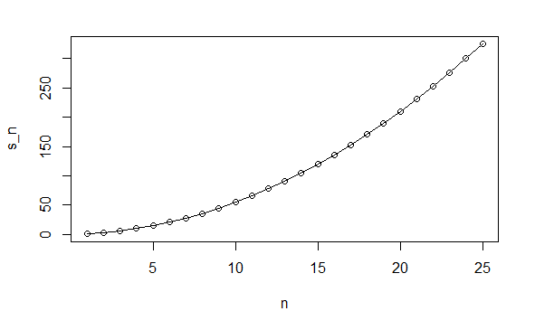

```r
plot(n, s_n)
lines(n, n*(n+1)/2)
```

## 4.5. Vectorization and functionals

In R `vectorization` is preferred over for-loops since it results in shorter and clearer code. **A `vectorized` function is a function that will apply the same operation on each of the vectors.**

```r
x <- 1:10
sqrt(x)
```

```
 [1] 1.000000 1.414214 1.732051 2.000000 2.236068 2.449490 2.645751
 [8] 2.828427 3.000000 3.162278
```

```r
y <- 1:10
x*y
```

```
 [1]   1   4   9  16  25  36  49  64  81 100
```

To make this calculation, there is no need for for-loops. However, not all functions work this way. **For instance, the function `compute_s_n` doesn’t work element-wise since it is expecting a scalar. This piece of code doesn’t run the function on each entry of `n`**:

```r
n <- 1:25
compute_s_n(n)
```

```
numerical expression has 25 elements: only the first used
```

```
[1] 1
```

`Functionals` are functions that help us apply the same function to each entry in a vector, matrix, data frame or list. `sapply` is a functional that operates on numeric, logical and character vectors. This function permits us to **perform element-wise operations on any function.** :

```r
x <- 1:10
sapply(x, sqrt)
```

```
 [1] 1.000000 1.414214 1.732051 2.000000 2.236068 2.449490 2.645751
 [8] 2.828427 3.000000 3.162278
```

Each element of `x` is passed on to the function `sqrt` and the result is resulted. These results are concatenated. In this case, the result is a vector of the same length as the original `x`. This implies that the for-loop above can be written as follows :

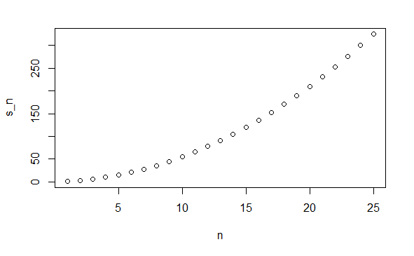

```r
n <- 1:25
s_n <- sapply(n, compute_s_n)
plot(n, s_n)
```

## 4.6. Exercises

1. What will this conditional expression return?

```r
x <- c(1,2,-3,4)

if(all(x>0)){
  print("All Postives")
} else{
  print("Not all positives")
}
```

```
[1] "Not all positives"
```

My answer : Not all positives.

2. Which of the following expressions is always `FALSE` when at least one entry of a logical vector `x` is TRUE?

A. `all(x)` B. `any(x)` C. `any(!x)` **D.** `all(!x)`

My answer : If we think about the result of `!x`, we can easily solve it.

a b b b -> b a a a : `all(!x)` is `FALSE`.

a a b b -> b b a a : `all(!x)` is `FALSE`.

a a a b -> b b b a : `all(!x)` is `FALSE`.

a a a a -> b b b b : `all(!x)` is `FALSE`.

3. The function `nchar` tells you how many characters long a character vector is. Write a line of code that assigns to the object `new_names` the state abbreviation when the state name is longer than 8 characters.

My answer (1)

```r
m <- length(murders$abb)
ind <- 1:m
if(nchar(murders$abb[ind]) > 8){
  new_names <- murders$abb[ind]
}
```

```
the condition has length > 1 and only the first element will be used
```

```r
new_names
```

```
Error: object 'new_names' not found
```

At first, I thought it was a question that I had to use the index to put all the vectors together, but this problem doesn’t seem to require such a complicated code. And according to the error message, the code I wrote seems to be incorrect in the grammar of `if` sentence. The code I wrote seems to be in the form of the `if` sentence used in C language rather than R. **I think I should study the `if` grammar in both languages again to make sure the difference.**

My answer (2)

```r
new_names <- ifelse(nchar(murders$state) > 8, murders$abb, murders$state)
```

My answer

```r
sum_n <- function(n){
  x <- 1:n
    sum(x)
}
sum_n(5000)
```

```
[1] 12502500
```

OK, but I referred to the explanation. More practice is needed so that I can solve it without looking at the explanation.

7. Write a function `compute_s_n` that for any given n computes the sum Sn = 1^2 + 2^2 +…+n^2. Report the value of the sum when n = 10.

My answer

```r
compute_s_n <- function(n){
  x <- 1:n
  sum(x^2)
}
compute_s_n(10)
```

```
[1] 385
```

OK

8. Define an empty numerical vector `s_n` of size 25 using `s_n <- vector("numeric", 25)` and store in the results of s1, s2, …, s25 using a for-loop.

My answer

```r
s_n <- vector("numeric", 25)

for(i in 1:25){
  s_n[i] <- compute_s_n(i)
}
```

OK

9. Repeat exercise 8, but this time use `sapply`.

My answer

```r
x <- 1:25
sapply(x, compute_s_n)
```

```
 [1]    1    5   14   30   55   91  140  204  285  385  506  650  819
[14] 1015 1240 1496 1785 2109 2470 2870 3311 3795 4324 4900 5525
```

OK

10. Repeat exercise 8, but this time use `map_dbl`.

My answer

```r
#install.packages("purrr")
#library(purrr)
map_dbl(25, compute_s_n)
```

```
[1] 5525
```

11. Plot Sn versus n. Use points defined by n = 1,…,25.

My answer

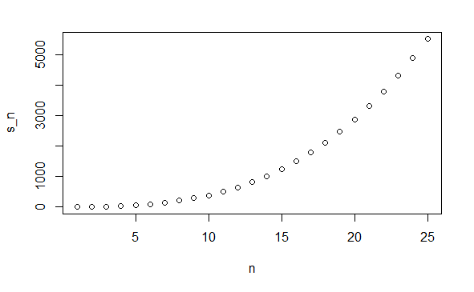

```r
for(n in 1:25){
  s_n[n] <- compute_s_n(n)
}
n <- 1:25
plot(n, s_n)
```

OK

12. Confirm that the formula for this sum is Sn = n(n+1)(2n+1)/6.

My answer

```r
n <- 25
compute_s_n(n) == n*(n+1)*(2*n+1)/6
```

```
[1] TRUE
```

OK